# Assignment 3

Author

Your Name

Published

October 3, 2024

# Instructions

Please submit your assignment as html file to me via email. Please call your assignment: “yourname_assignment3.html”. For example, I would submit something called “popescu_assignment3.html”. Please make sure that it is all in lower case.

To match the appearance of this template, ensure that your assignment preamble or YAML is set up as follows

```
---
title: "Assignment 3"
author: "Your Name"
date: "October 03, 2024"
format:
  html:
    toc: true
    number-sections: true
    colorlinks: true
    smooth-scroll: true
    embed-resources: true
---
```

Important: Headers like “Question” should be marked with a `#` (for example, `# Question`). This will format the text as a bold, larger header when the document is rendered, and it will also appear in the Table of Contents. For regular text, simply write it on the line below the header.

Please answer all the questions below.

```r
#Removing previous datasets in memory
rm(list = ls())
#Loading the relevant libraries
library(ggplot2)
library(gridExtra)
library(dplyr)
library(purrr)
library(ggpubr)
library(sf)
library(rnaturalearth)
library(rnaturalearthdata)
library(ggrepel)
```

# Question 1

Open the urbanization and life expectancy datasets.

- [Life expectancy data](https://www.dropbox.com/s/r16vn2a9om6zaxy/life-expectancy.csv?dl=0)
- [Urbanization data](https://www.dropbox.com/s/g7f69bdxu51jlxv/share-of-population-urban.csv?dl=0)

```r
setwd("/Users/bgpopescu/Dropbox/john_cabot/teaching/stats/assignment3/")
life_expectancy <- read.csv(file = './life-expectancy.csv')
urbanization <- read.csv(file = './share-of-population-urban.csv')
```

# Question 2

Clean the datasets by removing the countries with no labels or that are called “OWID_KOS”, “OWID_WRL”, calculate the averages for the entire period, and perform a left merge.

```r
#Step1: Calculating the mean
life_expectancy2<-life_expectancy%>%
  dplyr::group_by(Code, Entity)%>%
  dplyr::summarize(life_expectancy=mean(Life.expectancy.at.birth..historical.))

#Step2: Cleaning the Data
weird_labels <- c("OWID_KOS", "OWID_WRL", "")
clean_countries_life<-subset(life_expectancy2, !(Code %in% weird_labels))

#Step1: Calculating the mean
urbanization2<-urbanization%>%
  dplyr::group_by(Code, Entity)%>%
  dplyr::summarize(urbanization=mean(Urban.population....of.total.population.))

#Step2: Cleaning the Data
weird_labels <- c("OWID_KOS", "OWID_WRL", "")
clean_countries_urb<-subset(urbanization2, !(Code %in% weird_labels))
clean_countries_urb<-subset(clean_countries_urb, select = -c(Entity))

merge_df<-left_join(clean_countries_life, clean_countries_urb, by =c("Code"="Code"))
```

# Question 3

Get hold of and open in your computer’s memory a shape file of the world.

```r
world <- ne_countries(scale = "medium", returnclass = "sf")
world2<-subset(world, select = c(admin, adm0_a3, sovereignt, continent))
glimpse(world2)
```

```
Rows: 242
Columns: 5
$ admin      <chr> "Zimbabwe", "Zambia", "Yemen", "Vietnam", "Venezuela", "Vat…
$ adm0_a3    <chr> "ZWE", "ZMB", "YEM", "VNM", "VEN", "VAT", "VUT", "UZB", "UR…
$ sovereignt <chr> "Zimbabwe", "Zambia", "Yemen", "Vietnam", "Venezuela", "Vat…
$ continent  <chr> "Africa", "Africa", "Asia", "Asia", "South America", "Europ…
$ geometry   <MULTIPOLYGON [°]> MULTIPOLYGON (((31.28789 -2..., MULTIPOLYGON (…
```

# Question 4

Merge the dataframe to the spatial dataframe. What are the countries that are in your spatial dataframe and that are not in your dataframe.

```r
#Step1: Merging dataset
merged<-left_join(world2, merge_df, by = c("adm0_a3" = "Code"))
#Step2: Creating list of codes for the spatial df
ctries_sp<-world2$adm0_a3
ctries_sp
```

```
  [1] "ZWE" "ZMB" "YEM" "VNM" "VEN" "VAT" "VUT" "UZB" "URY" "FSM" "MHL" "MNP"
 [13] "VIR" "GUM" "ASM" "PRI" "USA" "SGS" "IOT" "SHN" "PCN" "AIA" "FLK" "CYM"
 [25] "BMU" "VGB" "TCA" "MSR" "JEY" "GGY" "IMN" "GBR" "ARE" "UKR" "UGA" "TKM"
 [37] "TUR" "TUN" "TTO" "TON" "TGO" "TLS" "THA" "TZA" "TJK" "TWN" "SYR" "CHE"
 [49] "SWE" "SWZ" "SUR" "SDS" "SDN" "LKA" "ESP" "KOR" "ZAF" "SOM" "SOL" "SLB"
 [61] "SVK" "SVN" "SGP" "SLE" "SYC" "SRB" "SEN" "SAU" "STP" "SMR" "WSM" "VCT"
 [73] "LCA" "KNA" "RWA" "RUS" "ROU" "QAT" "PRT" "POL" "PHL" "PER" "PRY" "PNG"
 [85] "PAN" "PLW" "PAK" "OMN" "NOR" "PRK" "NGA" "NER" "NIC" "NZL" "NIU" "COK"
 [97] "NLD" "ABW" "CUW" "NPL" "NRU" "NAM" "MOZ" "MAR" "SAH" "MNE" "MNG" "MDA"
[109] "MCO" "MEX" "MUS" "MRT" "MLT" "MLI" "MDV" "MYS" "MWI" "MDG" "MKD" "LUX"
[121] "LTU" "LIE" "LBY" "LBR" "LSO" "LBN" "LVA" "LAO" "KGZ" "KWT" "KOS" "KIR"
[133] "KEN" "KAZ" "JOR" "JPN" "JAM" "ITA" "ISR" "PSX" "IRL" "IRQ" "IRN" "IDN"
[145] "IND" "ISL" "HUN" "HND" "HTI" "GUY" "GNB" "GIN" "GTM" "GRD" "GRC" "GHA"
[157] "DEU" "GEO" "GMB" "GAB" "FRA" "SPM" "WLF" "MAF" "BLM" "PYF" "NCL" "ATF"
[169] "ALD" "FIN" "FJI" "ETH" "EST" "ERI" "GNQ" "SLV" "EGY" "ECU" "DOM" "DMA"
[181] "DJI" "GRL" "FRO" "DNK" "CZE" "CYN" "CYP" "CUB" "HRV" "CIV" "CRI" "COD"
[193] "COG" "COM" "COL" "CHN" "MAC" "HKG" "CHL" "TCD" "CAF" "CPV" "CAN" "CMR"
[205] "KHM" "MMR" "BDI" "BFA" "BGR" "BRN" "BRA" "BWA" "BIH" "BOL" "BTN" "BEN"
[217] "BLZ" "BEL" "BLR" "BRB" "BGD" "BHR" "BHS" "AZE" "AUT" "AUS" "IOA" "HMD"
[229] "NFK" "ATC" "ARM" "ARG" "ATG" "AGO" "AND" "DZA" "ALB" "AFG" "KAS" "ATA"
[241] "SXM" "TUV"
```

```r
merged$admin[merged$continent=="Africa"]
```

```
 [1] "Zimbabwe"                         "Zambia"
 [3] "Uganda"                           "Tunisia"
 [5] "Togo"                             "United Republic of Tanzania"
 [7] "eSwatini"                         "South Sudan"
 [9] "Sudan"                            "South Africa"
[11] "Somalia"                          "Somaliland"
[13] "Sierra Leone"                     "Senegal"
[15] "São Tomé and Principe"            "Rwanda"
[17] "Nigeria"                          "Niger"
[19] "Namibia"                          "Mozambique"
[21] "Morocco"                          "Western Sahara"
[23] "Mauritania"                       "Mali"
[25] "Malawi"                           "Madagascar"
[27] "Libya"                            "Liberia"
[29] "Lesotho"                          "Kenya"
[31] "Guinea-Bissau"                    "Guinea"
[33] "Ghana"                            "Gambia"
[35] "Gabon"                            "Ethiopia"
[37] "Eritrea"                          "Equatorial Guinea"
[39] "Egypt"                            "Djibouti"
[41] "Ivory Coast"                      "Democratic Republic of the Congo"
[43] "Republic of the Congo"            "Comoros"
[45] "Chad"                             "Central African Republic"
[47] "Cabo Verde"                       "Cameroon"
[49] "Burundi"                          "Burkina Faso"
[51] "Botswana"                         "Benin"
[53] "Angola"                           "Algeria"
```

```r
#Step3: Creating list of codes for the df
ctries_df<-clean_countries_life$Code
ctries_df
```

```
  [1] "ABW" "AFG" "AGO" "AIA" "ALB" "AND" "ARE" "ARG" "ARM" "ASM" "ATG" "AUS"
 [13] "AUT" "AZE" "BDI" "BEL" "BEN" "BES" "BFA" "BGD" "BGR" "BHR" "BHS" "BIH"
 [25] "BLR" "BLZ" "BMU" "BOL" "BRA" "BRB" "BRN" "BTN" "BWA" "CAF" "CAN" "CHE"
 [37] "CHL" "CHN" "CIV" "CMR" "COD" "COG" "COK" "COL" "COM" "CPV" "CRI" "CUB"
 [49] "CUW" "CYM" "CYP" "CZE" "DEU" "DJI" "DMA" "DNK" "DOM" "DZA" "ECU" "EGY"
 [61] "ERI" "ESH" "ESP" "EST" "ETH" "FIN" "FJI" "FLK" "FRA" "FRO" "FSM" "GAB"
 [73] "GBR" "GEO" "GGY" "GHA" "GIB" "GIN" "GLP" "GMB" "GNB" "GNQ" "GRC" "GRD"
 [85] "GRL" "GTM" "GUF" "GUM" "GUY" "HKG" "HND" "HRV" "HTI" "HUN" "IDN" "IMN"
 [97] "IND" "IRL" "IRN" "IRQ" "ISL" "ISR" "ITA" "JAM" "JEY" "JOR" "JPN" "KAZ"
[109] "KEN" "KGZ" "KHM" "KIR" "KNA" "KOR" "KWT" "LAO" "LBN" "LBR" "LBY" "LCA"
[121] "LIE" "LKA" "LSO" "LTU" "LUX" "LVA" "MAC" "MAF" "MAR" "MCO" "MDA" "MDG"
[133] "MDV" "MEX" "MHL" "MKD" "MLI" "MLT" "MMR" "MNE" "MNG" "MNP" "MOZ" "MRT"
[145] "MSR" "MTQ" "MUS" "MWI" "MYS" "MYT" "NAM" "NCL" "NER" "NGA" "NIC" "NIU"
[157] "NLD" "NOR" "NPL" "NRU" "NZL" "OMN" "PAK" "PAN" "PER" "PHL" "PLW" "PNG"
[169] "POL" "PRI" "PRK" "PRT" "PRY" "PSE" "PYF" "QAT" "REU" "ROU" "RUS" "RWA"
[181] "SAU" "SDN" "SEN" "SGP" "SHN" "SLB" "SLE" "SLV" "SMR" "SOM" "SPM" "SRB"
[193] "SSD" "STP" "SUR" "SVK" "SVN" "SWE" "SWZ" "SXM" "SYC" "SYR" "TCA" "TCD"
[205] "TGO" "THA" "TJK" "TKL" "TKM" "TLS" "TON" "TTO" "TUN" "TUR" "TUV" "TWN"
[217] "TZA" "UGA" "UKR" "URY" "USA" "UZB" "VAT" "VCT" "VEN" "VGB" "VIR" "VNM"
[229] "VUT" "WLF" "WSM" "YEM" "ZAF" "ZMB" "ZWE"
```

```r
#Step4: Calculating the difference - what countries are in one vs. the other.
countries_dif<-setdiff(ctries_sp, ctries_df)
countries_dif
```

```
 [1] "SGS" "IOT" "PCN" "SDS" "SOL" "SAH" "KOS" "PSX" "BLM" "ATF" "ALD" "CYN"
[13] "IOA" "HMD" "NFK" "ATC" "KAS" "ATA"
```

```r
#Step5: Listing the difference
world3<-subset(world2, adm0_a3 %in% countries_dif)
world3$admin
```

```
 [1] "South Georgia and the Islands"       "British Indian Ocean Territory"
 [3] "Pitcairn Islands"                    "South Sudan"
 [5] "Somaliland"                          "Western Sahara"
 [7] "Kosovo"                              "Palestine"
 [9] "Saint Barthelemy"                    "French Southern and Antarctic Lands"
[11] "Aland"                               "Northern Cyprus"
[13] "Indian Ocean Territories"            "Heard Island and McDonald Islands"
[15] "Norfolk Island"                      "Ashmore and Cartier Islands"
[17] "Siachen Glacier"                     "Antarctica"
```

# Question 5

Create a map that shows life expectancy in Africa. Use the follwing countries to set the extent of your map: North-Tunisia, South-South Africa, West-Mauritania, East-Somalia. Note: do not simply subset the data based on continent value. Also add some error to your coordinates so that your map does not look too squished (recommended error of 7).

```r
#Step1: Select the country
tunisia<-subset(world2, admin=="Tunisia")
#Step2: Extracting its coordinates
max_lat_y<-st_bbox(tunisia)["ymax"]
max_lat_y
```

```
    ymax
37.34038
```

```r
#Step1: Select the country
southafrica<-subset(world2, admin=="South Africa")
#Step2: Extracting its coordinates
st_bbox(southafrica)
```

```
     xmin      ymin      xmax      ymax
 16.44756 -46.96289  37.88770 -22.14629
```

```r
min_lat_y<-st_bbox(southafrica)["ymin"]
min_lat_y
```

```
     ymin
-46.96289
```

```r
#Step1: Select the country
mauritania<-subset(world2, admin=="Mauritania")
#Step2: Extracting its coordinates
st_bbox(mauritania)
```

```
      xmin       ymin       xmax       ymax
-17.063965  14.745361  -4.822607  27.285937
```

```r
min_lon_x<-st_bbox(mauritania)["xmin"]
min_lon_x
```

```
     xmin
-17.06396
```

```r
#Step1: Select the country
somalia<-subset(world2, admin=="Somalia")
#Step2: Extracting its coordinates
st_bbox(somalia)
```

```
     xmin      ymin      xmax      ymax
40.964453 -1.695312 51.390234 11.983691
```

```r
max_lon_x<-st_bbox(somalia)["xmax"]
max_lon_x
```

```
    xmax
51.39023
```

We now make the map:

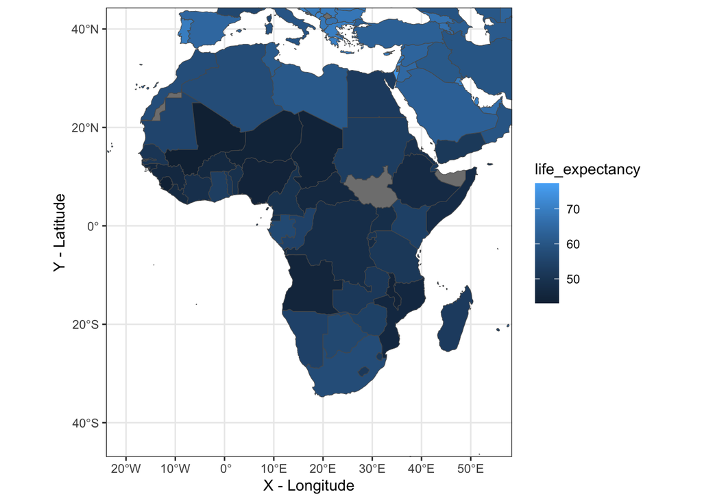

```r
error <- 7
figure1<-ggplot() +
    geom_sf() +
    geom_sf(data = merged, aes(fill = life_expectancy))+
    theme_bw()+
    xlab("X - Longitude") + ylab("Y - Latitude")+
    coord_sf(xlim = c(min_lon_x-error, max_lon_x+error),
             ylim = c(min_lat_y, max_lat_y+error), expand = FALSE)
figure1
```

# Question 6

Compare African countries to the rest of the world. Is life expectancy higher, lower, or the same as the rest of the world? Perform relevant tests.

```r
#Step1: Creating the sample of African countries
sample_africa<-subset(merged, continent=="Africa")
#Step2: Removing Africa from the world
sample_world_no_africa<-subset(merged, continent!="Africa")

mean(sample_africa$life_expectancy, na.rm=T)
```

```
[1] 50.83892
```

```r
mean(sample_world_no_africa$life_expectancy, na.rm=T)
```

```
[1] 65.02682
```

```r
merged$type<-NA
merged$type<-"rest"
merged$type[merged$continent=="Africa"]<-"africa"
```

```r
merged$type<-NA
merged$type<-"rest"
merged$type[merged$continent=="Africa"]<-"africa"
t.test(life_expectancy ~ type, data = merged)
```

```
    Welch Two Sample t-test

data:  life_expectancy by type
t = -16.834, df = 107.86, p-value < 2.2e-16
alternative hypothesis: true difference in means between group africa and group rest is not equal to 0
95 percent confidence interval:
 -15.85848 -12.51732
sample estimates:
mean in group africa   mean in group rest
            50.83892             65.02682
```

```r
t.test(sample_africa$life_expectancy,
        mu=mean(sample_world_no_africa$life_expectancy, na.rm=T),
        alternative = c("greater"))
```

```
    One Sample t-test

data:  sample_africa$life_expectancy
t = -20.802, df = 50, p-value = 1
alternative hypothesis: true mean is greater than 65.02682
95 percent confidence interval:
 49.69585      Inf
sample estimates:
mean of x
 50.83892
```

```r
t.test(sample_africa$life_expectancy,
        mu=mean(sample_world_no_africa$life_expectancy, na.rm=T),
        alternative = c("less"))
```

```
    One Sample t-test

data:  sample_africa$life_expectancy
t = -20.802, df = 50, p-value < 2.2e-16
alternative hypothesis: true mean is less than 65.02682
95 percent confidence interval:
     -Inf 51.98199
sample estimates:
mean of x
 50.83892
```

```r
t.test(sample_africa$life_expectancy,
        mu=mean(sample_world_no_africa$life_expectancy, na.rm=T),
        alternative = c("two.sided"))
```

```
    One Sample t-test

data:  sample_africa$life_expectancy
t = -20.802, df = 50, p-value < 2.2e-16
alternative hypothesis: true mean is not equal to 65.02682
95 percent confidence interval:
 49.46896 52.20888
sample estimates:
mean of x
 50.83892
```

The results indicate that life expectancy in Africa is not equal statistically to that of the world. In fact, life expectancy is statistically lower than that of the world. Life expectancy in our African sample is 50.83 and 65 in the rest of the world.

# Question 7

Compare African countries to the rest of the world. Is urbanization higher, lower, or the same, as the rest of the world? Perform relevant tests.

```r
merged$type<-NA
merged$type<-"rest"
merged$type[merged$continent=="Africa"]<-"africa"
t.test(urbanization ~ type, data = merged, alternative = c("greater"))
```

```
    Welch Two Sample t-test

data:  urbanization by type
t = -9.0282, df = 131.46, p-value = 1
alternative hypothesis: true difference in means between group africa and group rest is greater than 0
95 percent confidence interval:
 -29.74802       Inf
sample estimates:
mean in group africa   mean in group rest
            32.18961             57.32560
```

We don’t reject the H0 and conclude that the true difference in means between Africa and the rest of the world is not greater.

```r
merged$type<-NA
merged$type<-"rest"
merged$type[merged$continent=="Africa"]<-"africa"
t.test(urbanization ~ type, data = merged, alternative = c("less"))
```

```
    Welch Two Sample t-test

data:  urbanization by type
t = -9.0282, df = 131.46, p-value = 9.381e-16
alternative hypothesis: true difference in means between group africa and group rest is less than 0
95 percent confidence interval:
      -Inf -20.52397
sample estimates:
mean in group africa   mean in group rest
            32.18961             57.32560
```

Here we reject the H0 and conclude that the true difference in means between the group africa and group rest is less than 0.

```r
t.test(urbanization ~ type, data = merged, alternative = c("two.sided"))
```

```
    Welch Two Sample t-test

data:  urbanization by type
t = -9.0282, df = 131.46, p-value = 1.876e-15
alternative hypothesis: true difference in means between group africa and group rest is not equal to 0
95 percent confidence interval:
 -30.64353 -19.62846
sample estimates:
mean in group africa   mean in group rest
            32.18961             57.32560
```

We reject the H0 and conclude that the true difference in means between group africa and group rest is is not equal to 0.

# Question 8

Create a box plot for life expectancy comparing Africa to the rest of the world.

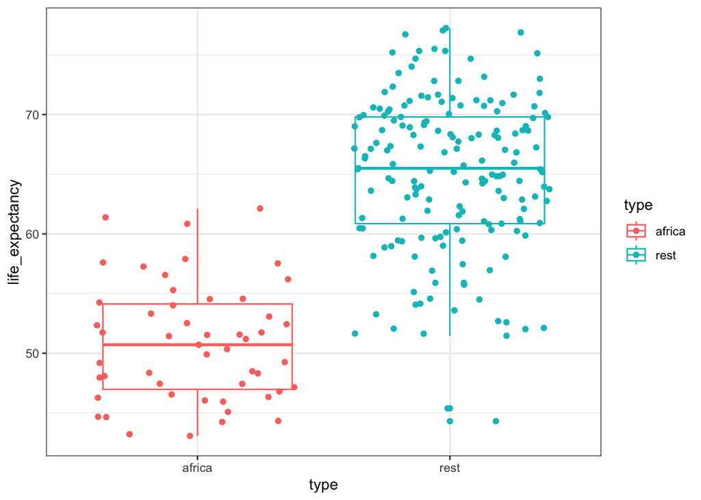

```r
ggplot(merged, aes(x = type, y = life_expectancy, color = type)) +
  geom_boxplot() +
  geom_jitter() +
  theme_bw()
```

# Question 9

Create a box plot for urbanization comparing Africa to the rest of the world.

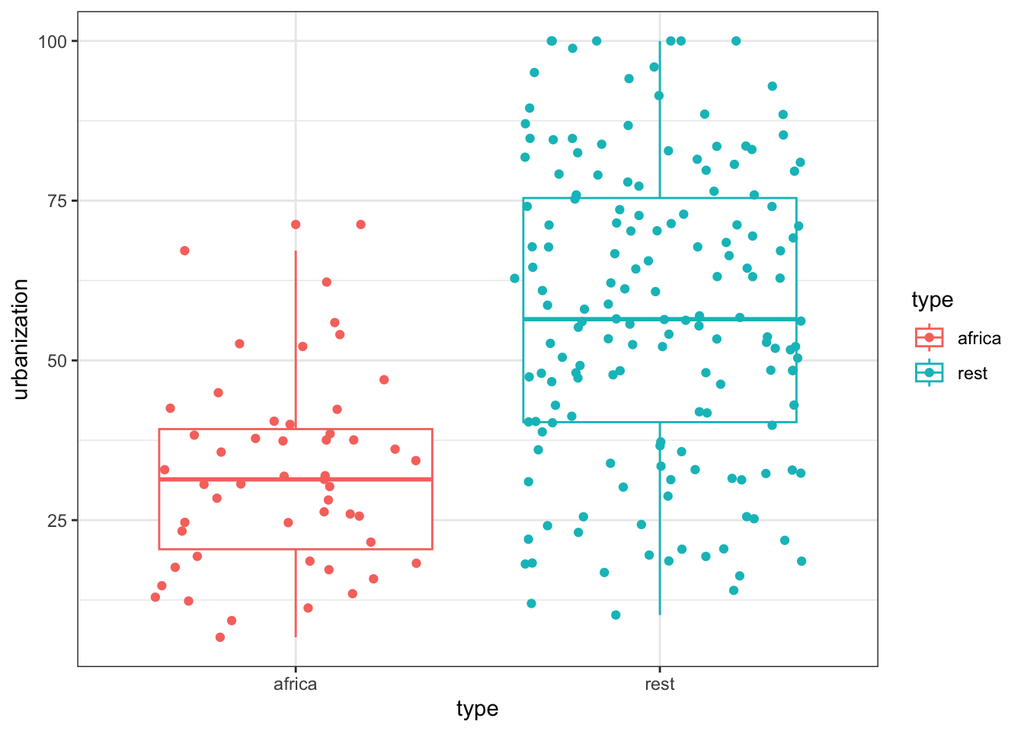

```r
ggplot(merged, aes(x = type, y = urbanization, color = type)) +
  geom_boxplot() +
  geom_jitter() +
  theme_bw()
```

# Question 10

Create two maps side by side with life expectancy in Africa in 1980 and 2010. Note, make sure that you have one legend for both maps and that the the min and max values are the same.

```r
names(life_expectancy)[4]<-"life_expectancy_values"
life_expectancy_1980<-subset(life_expectancy, Year==1980)
world_1980<-left_join(world2, life_expectancy_1980, by = c("adm0_a3"="Code"))
glimpse(world_1980)
```

```
Rows: 242
Columns: 8
$ admin                  <chr> "Zimbabwe", "Zambia", "Yemen", "Vietnam", "Vene…
$ adm0_a3                <chr> "ZWE", "ZMB", "YEM", "VNM", "VEN", "VAT", "VUT"…
$ sovereignt             <chr> "Zimbabwe", "Zambia", "Yemen", "Vietnam", "Vene…
$ continent              <chr> "Africa", "Africa", "Asia", "Asia", "South Amer…
$ Entity                 <chr> "Zimbabwe", "Zambia", "Yemen", "Vietnam", "Vene…
$ Year                   <int> 1980, 1980, 1980, 1980, 1980, 1980, 1980, 1980,…
$ life_expectancy_values <dbl> 58.7, 54.1, 50.7, 66.2, 68.8, 74.1, 61.1, 63.0,…
$ geometry               <MULTIPOLYGON [°]> MULTIPOLYGON (((31.28789 -2..., MU…
```

```r
names(life_expectancy)[4]<-"life_expectancy_values"
life_expectancy_2010<-subset(life_expectancy, Year==2010)
world_2010<-left_join(world2, life_expectancy_2010, by = c("adm0_a3"="Code"))
glimpse(world_2010)
```

```
Rows: 242
Columns: 8
$ admin                  <chr> "Zimbabwe", "Zambia", "Yemen", "Vietnam", "Vene…
$ adm0_a3                <chr> "ZWE", "ZMB", "YEM", "VNM", "VEN", "VAT", "VUT"…
$ sovereignt             <chr> "Zimbabwe", "Zambia", "Yemen", "Vietnam", "Vene…
$ continent              <chr> "Africa", "Africa", "Asia", "Asia", "South Amer…
$ Entity                 <chr> "Zimbabwe", "Zambia", "Yemen", "Vietnam", "Vene…
$ Year                   <int> 2010, 2010, 2010, 2010, 2010, 2010, 2010, 2010,…
$ life_expectancy_values <dbl> 50.7, 56.8, 67.3, 73.5, 72.9, 81.5, 69.6, 69.2,…
$ geometry               <MULTIPOLYGON [°]> MULTIPOLYGON (((31.28789 -2..., MU…
```

```r
vmax <- max(life_expectancy$life_expectancy_values, na.rm=T)
vmin <- min(life_expectancy$life_expectancy_values, na.rm=T)
```

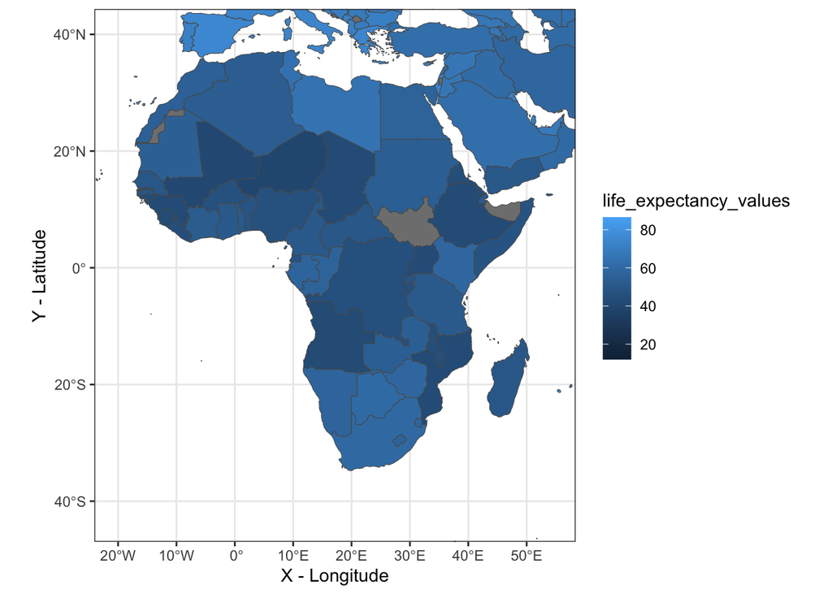

```r
figure2<-ggplot() +
    geom_sf(data = world_1980, aes(fill = life_expectancy_values))+
    theme_bw()+
    xlab("X - Longitude") + ylab("Y - Latitude")+
    coord_sf(xlim = c(min_lon_x-error, max_lon_x+error),
             ylim = c(min_lat_y, max_lat_y+error), expand = FALSE)+
  scale_fill_gradient(limits=c(vmin, vmax))
figure2
```

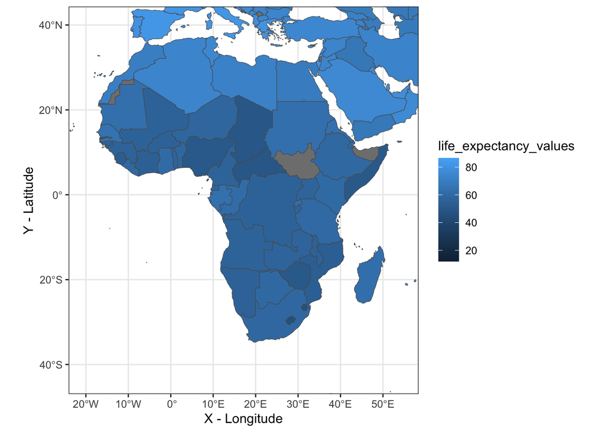

```r
figure3<-ggplot() +
    geom_sf(data = world_2010, aes(fill = life_expectancy_values))+
    theme_bw()+
    xlab("X - Longitude") + ylab("Y - Latitude")+
    coord_sf(xlim = c(min_lon_x-error, max_lon_x+error),
             ylim = c(min_lat_y, max_lat_y+error), expand = FALSE)+
  scale_fill_gradient(limits=c(vmin, vmax))
figure3
```

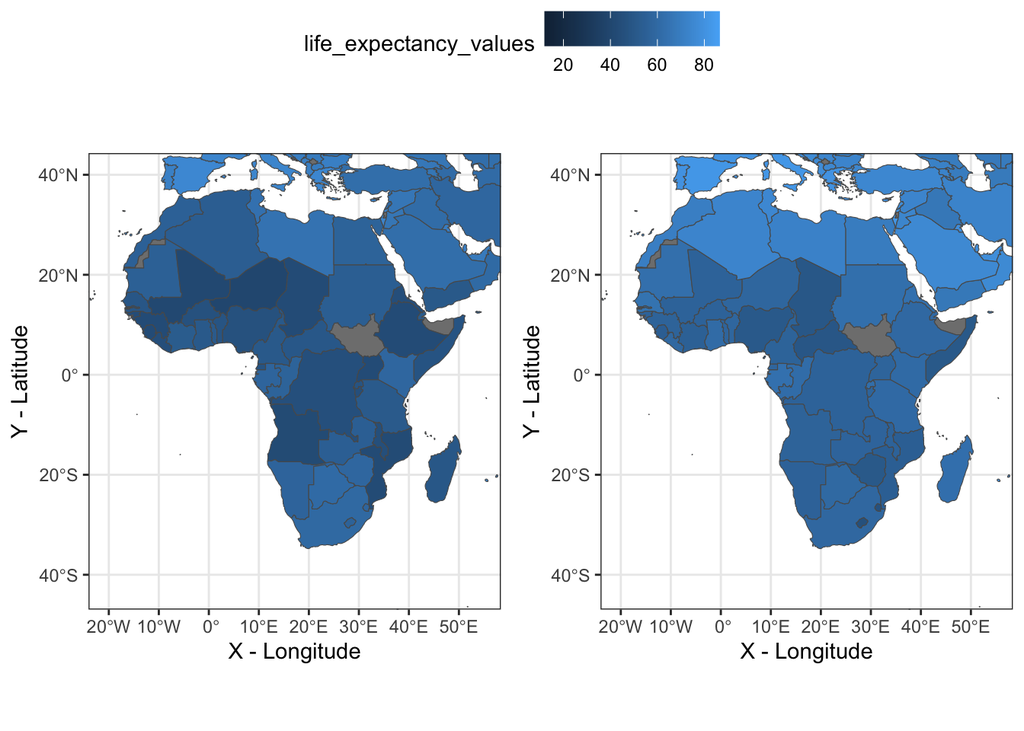

```r
ggarrange(figure2, figure3, ncol=2, common.legend = TRUE)
```

# Question 11

Map changes in life expectancy between 1980 and 2010 in Africa.

```r
life_expectancy_1980_2010<-subset(life_expectancy, Year %in% c(1980, 2010))
life_expectancy_1980_2010b<-life_expectancy_1980_2010%>%
  dplyr::group_by(Code) %>%
  dplyr::summarise(differ=life_expectancy_values - lag(life_expectancy_values))
life_expectancy_1980_2010c<-subset(life_expectancy_1980_2010b, Code!="" & !is.na(differ))
glimpse(life_expectancy_1980_2010c)
```

```
Rows: 237
Columns: 2
Groups: Code [237]
$ Code   <chr> "ABW", "AFG", "AGO", "AIA", "ALB", "AND", "ARE", "ARG", "ARM", …
$ differ <dbl> 4.3, 21.3, 14.3, 8.7, 7.4, 6.0, 9.8, 7.1, 7.0, 3.2, 3.6, 7.5, 7…
```

```r
world_change<-left_join(world2, life_expectancy_1980_2010c, by = c("adm0_a3"="Code"))
glimpse(world_change)
```

```
Rows: 242
Columns: 6
$ admin      <chr> "Zimbabwe", "Zambia", "Yemen", "Vietnam", "Venezuela", "Vat…
$ adm0_a3    <chr> "ZWE", "ZMB", "YEM", "VNM", "VEN", "VAT", "VUT", "UZB", "UR…
$ sovereignt <chr> "Zimbabwe", "Zambia", "Yemen", "Vietnam", "Venezuela", "Vat…
$ continent  <chr> "Africa", "Africa", "Asia", "Asia", "South America", "Europ…
$ differ     <dbl> -8.0, 2.7, 16.6, 7.3, 4.1, 7.4, 8.5, 6.2, 6.3, 7.0, 2.2, 8.…
$ geometry   <MULTIPOLYGON [°]> MULTIPOLYGON (((31.28789 -2..., MULTIPOLYGON (…
```

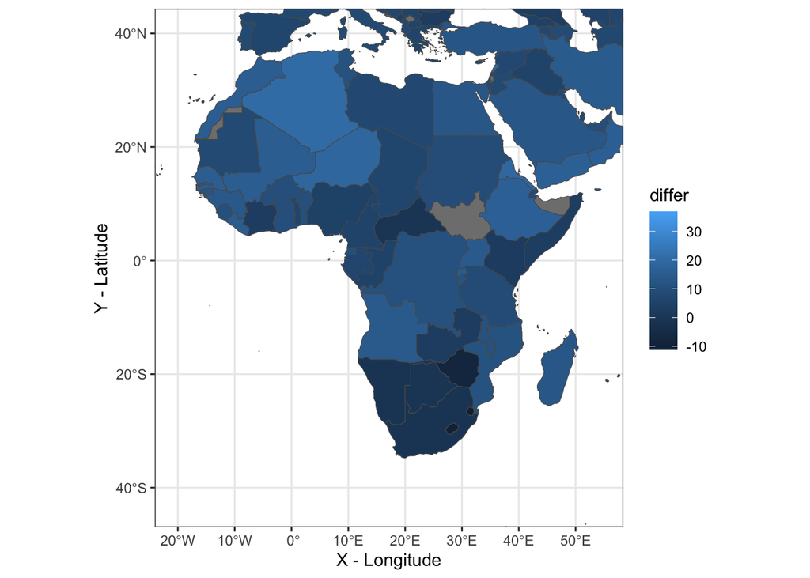

```r
figure4<-ggplot() +
    geom_sf(data = world_change, aes(fill = differ))+
    theme_bw()+
    xlab("X - Longitude") + ylab("Y - Latitude")+
    coord_sf(xlim = c(min_lon_x-error, max_lon_x+error),
             ylim = c(min_lat_y, max_lat_y+error), expand = FALSE)
figure4
```

# Question 12

What are the countries in Africa where people live shorter lives in 2010 than in 1980? How many years did they live in 1980 and how many years did they live in 2010.

```r
world_change_res<-subset(world_change, continent=="Africa")
world_change_resx<-subset(world_change_res, differ<0)
list_of_interest<-c(world_change_resx$admin)
list_of_interest
```

```
[1] "Zimbabwe"                 "eSwatini"
[3] "South Africa"             "Namibia"
[5] "Lesotho"                  "Central African Republic"
[7] "Botswana"
```

```r
world_change_res_1980<-subset(world_1980, admin %in% list_of_interest)
list_years_1980<-world_change_res_1980$life_expectancy
list_years_1980
```

```
[1] 58.7 57.8 59.8 56.8 56.1 49.9 60.6
```

```r
world_change_res_2010<-subset(world_2010, admin %in% list_of_interest)
list_years_2010<-world_change_res_2010$life_expectancy
list_years_2010
```

```
[1] 50.7 46.6 58.9 56.0 45.6 49.3 60.0
```

```r
d <- data.frame(list_of_interest,
                list_years_1980,
                list_years_2010)
d$diff<-d$list_years_2010-d$list_years_1980
d
```

| list_of_interest | list_years_1980 | list_years_2010 | diff |
| --- | --- | --- | --- |
| Zimbabwe | 58.7 | 50.7 | -8.0 |
| eSwatini | 57.8 | 46.6 | -11.2 |
| South Africa | 59.8 | 58.9 | -0.9 |
| Namibia | 56.8 | 56.0 | -0.8 |
| Lesotho | 56.1 | 45.6 | -10.5 |
| Central African Republic | 49.9 | 49.3 | -0.6 |
| Botswana | 60.6 | 60.0 | -0.6 |